# 二手车估价模型

# 二手车估价模型

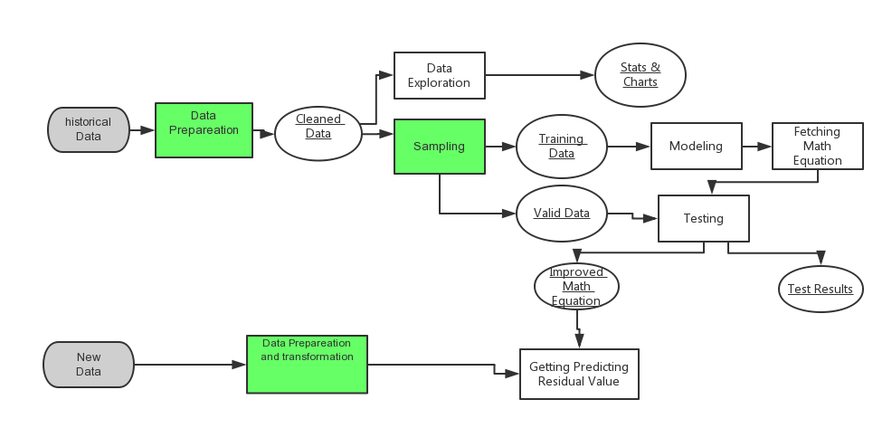

数据字典( 变量分类)  
汽车购买类数据，汽车本身参数

fld_status 信息状态(4类,在售,已售,撤销,逾期） 已售(455801, 64%),逾期(232890,33%),在售(24822,3%)

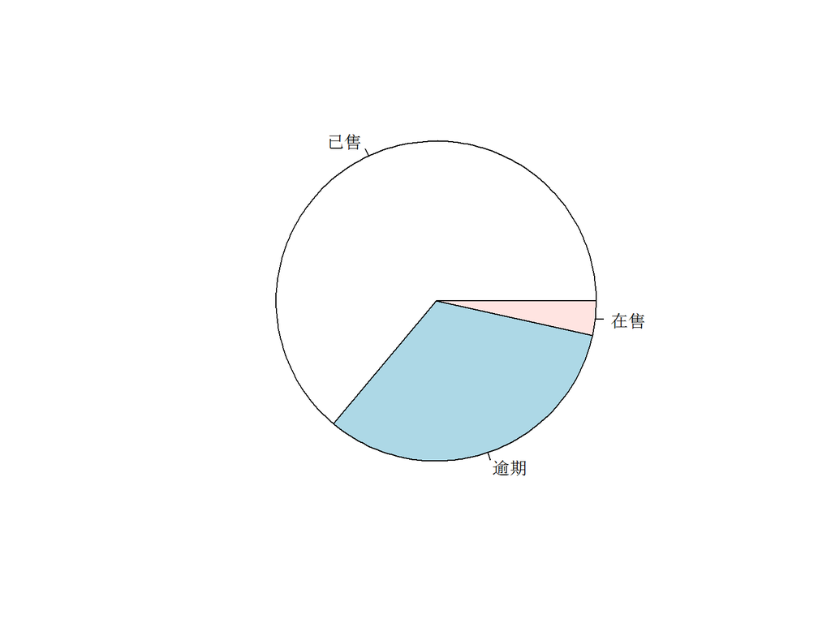

fld_estate 信息来源：

```
##
##            备案车     代理 代理经纪     个人     经纪
##   12.873    0.000    2.208   79.497    3.383    2.039
```

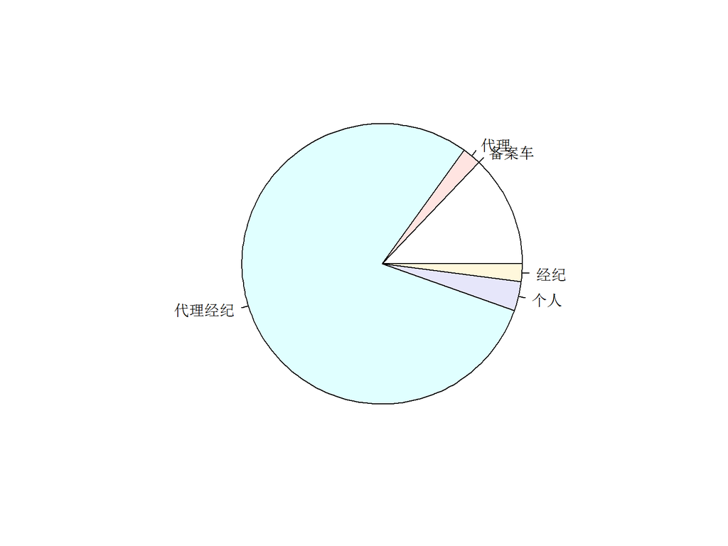

fld_id 经销商id(12662)  
fld_dealerclass经销商等级(按照车网的标准)

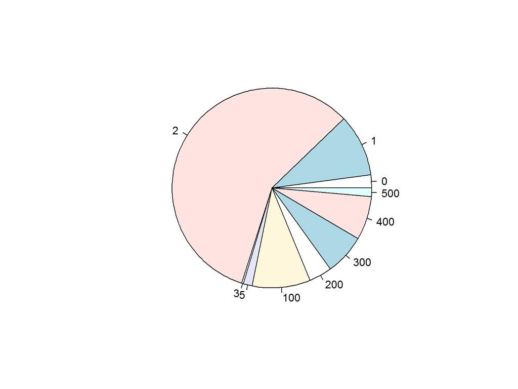

fld_market(523个市场 但有180564个没有值) fld_dealertype 经销商类型

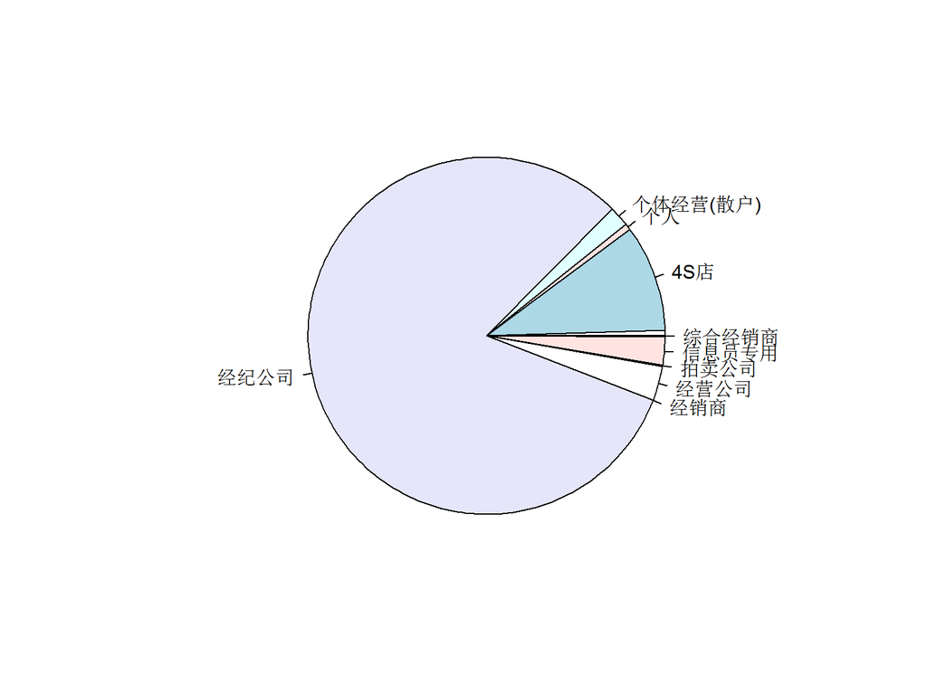

fld_createtime 信息首次上传日期,我们以后用这个时间作为二手汽车销售时间

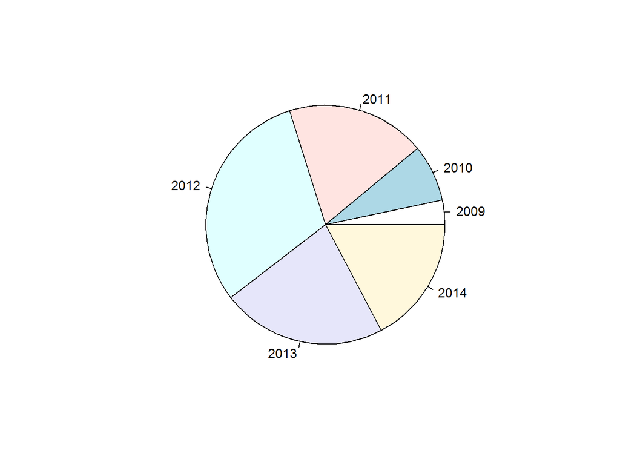

fld_szdmain 汽车交易省份

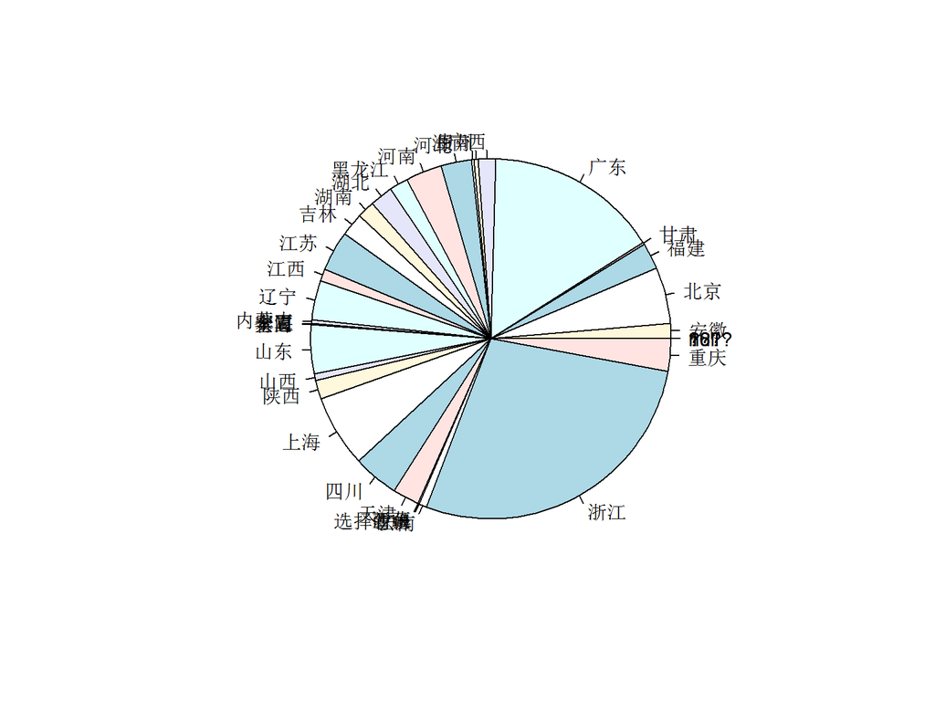

车辆本身参数(包括车型级别,车型,生产厂商,车辆生产年份,排量等)  
fld_level车型级别

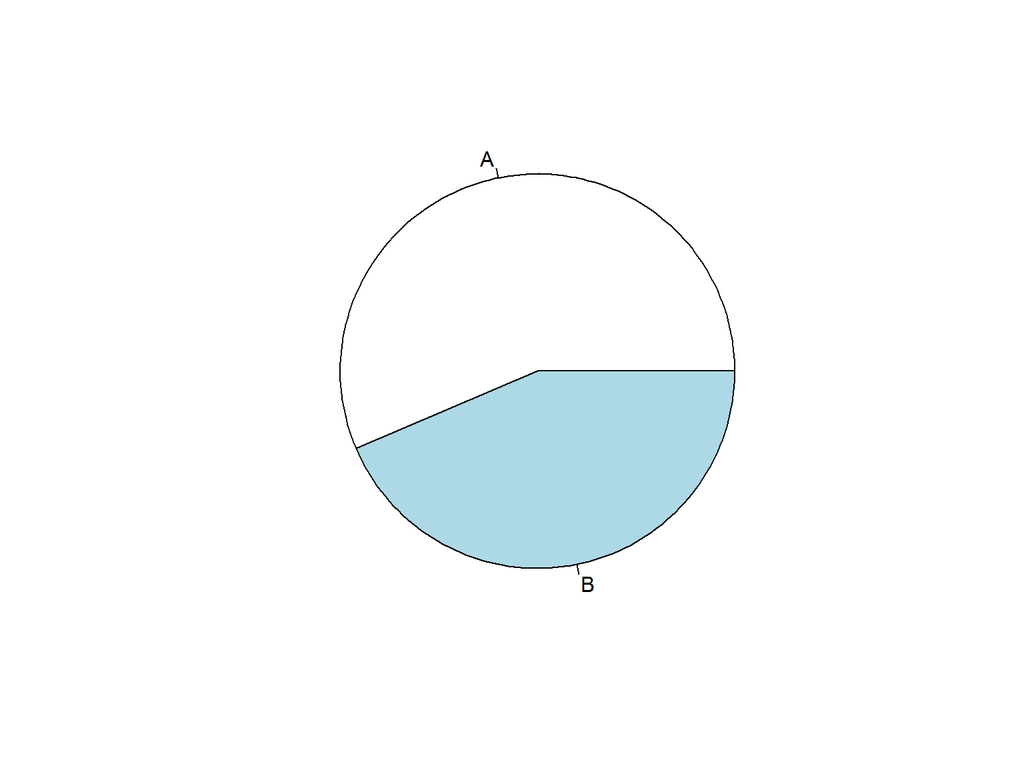

fld_iautosname生产厂商

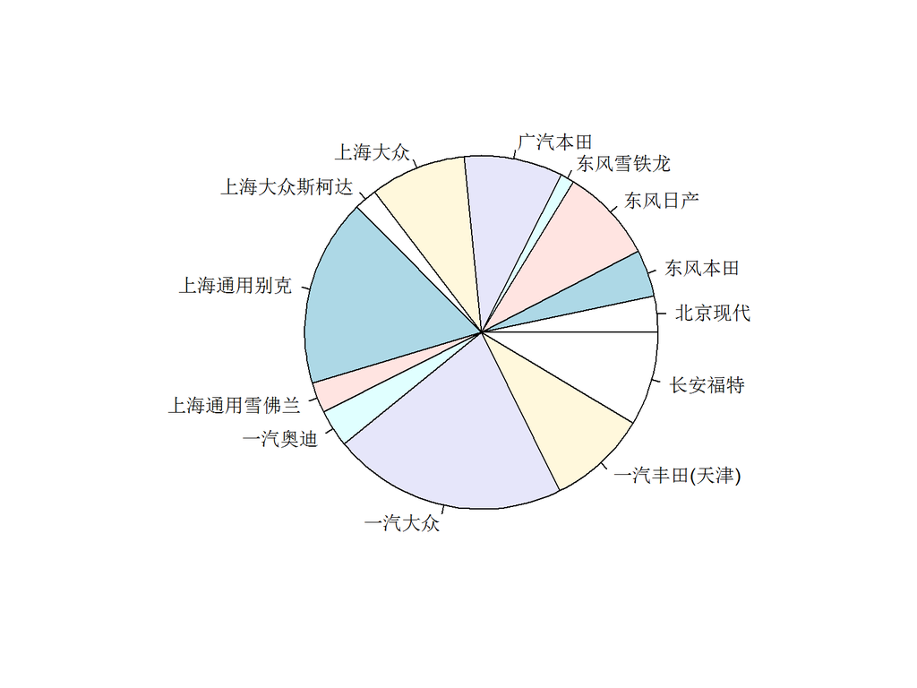

fld_ccsj车辆生产年份

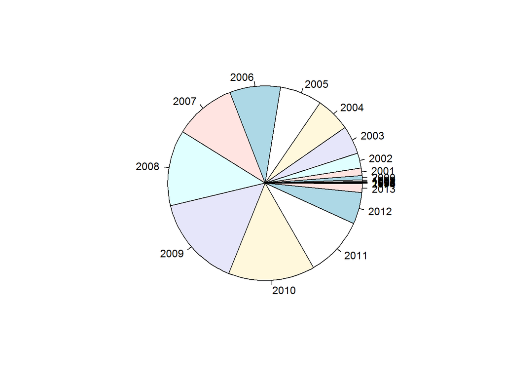

fld_serial品牌名称

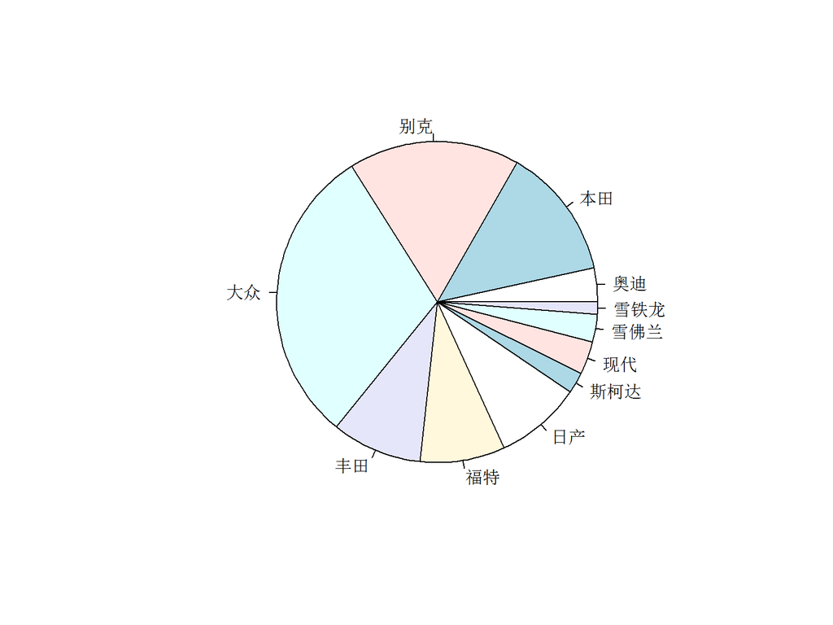

fld_model车系名称

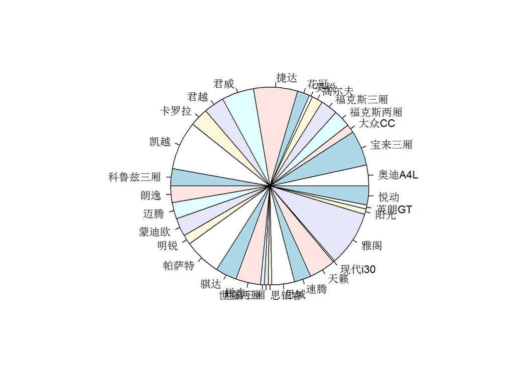

fld_trim_status款式是否在产

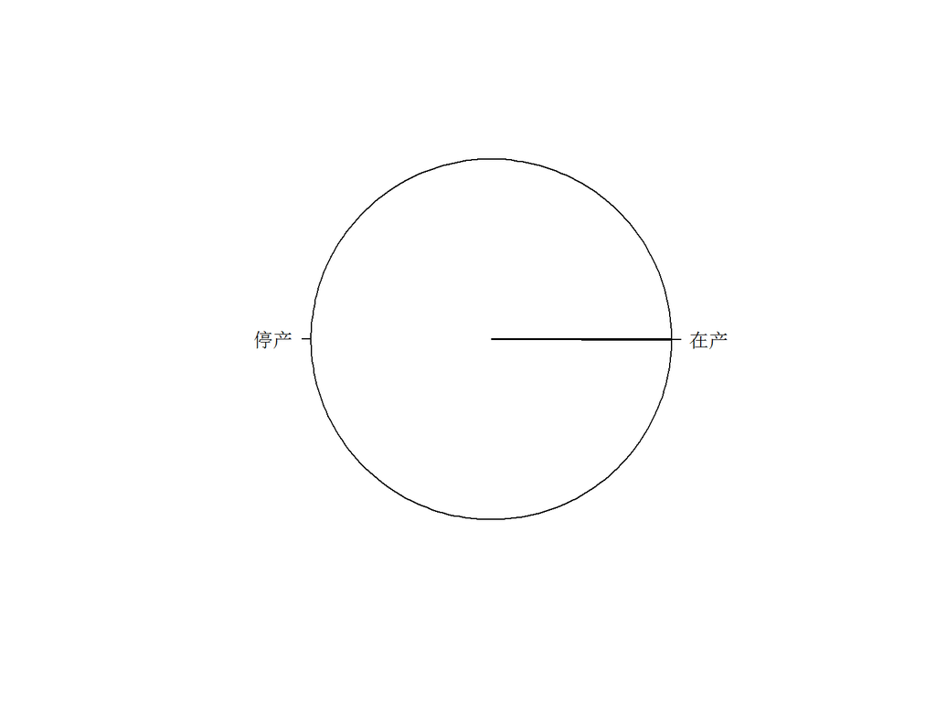

fld_pl排量

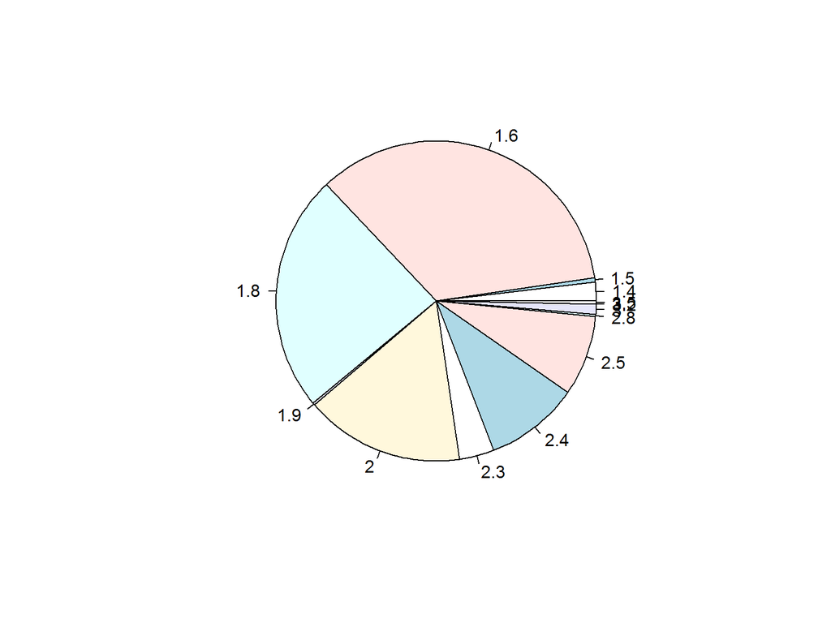

fld_ctlx车体类型(三厢二厢)

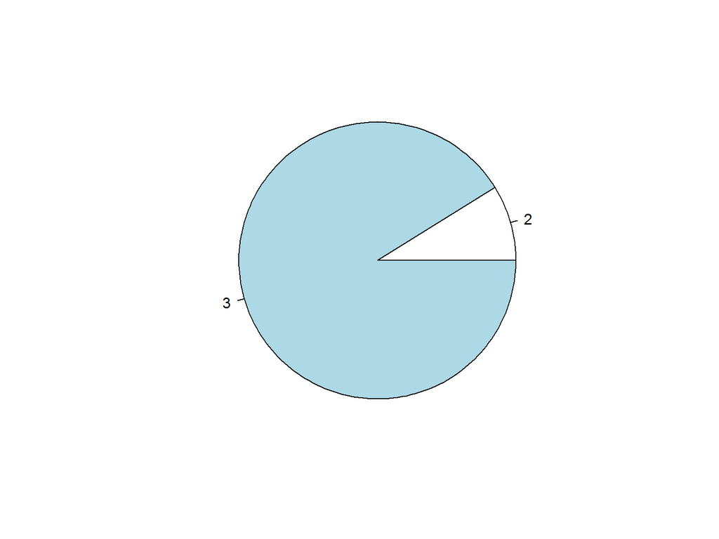

fld_qdfs驱动方式(1=前驱、2=后驱、3=四驱)

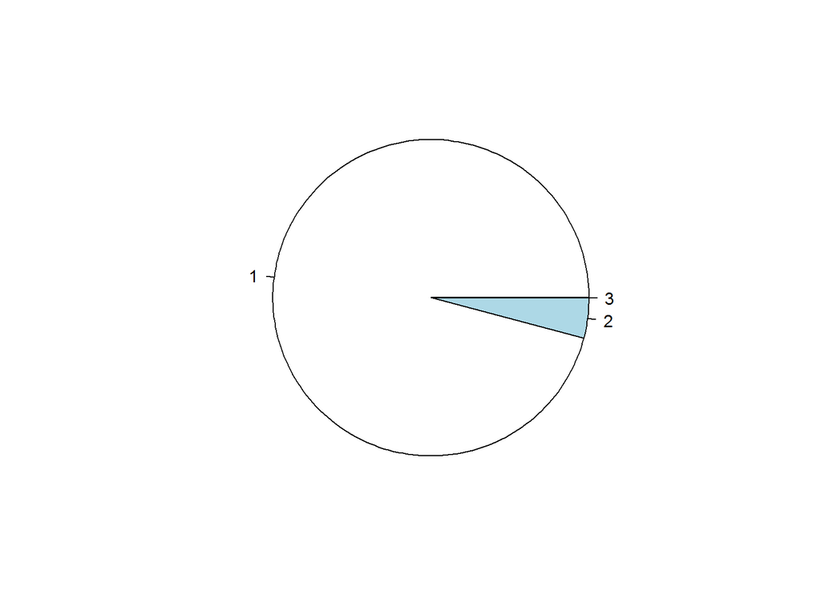

fld_jqfs进气方式（1 自然进气 2 机械增压 3 涡轮增压4 强涡轮增压 5 水冷式涡轮增压6 水冷式双涡轮增压）

```
##
##      1      2      3
## 599149     17 114347
```

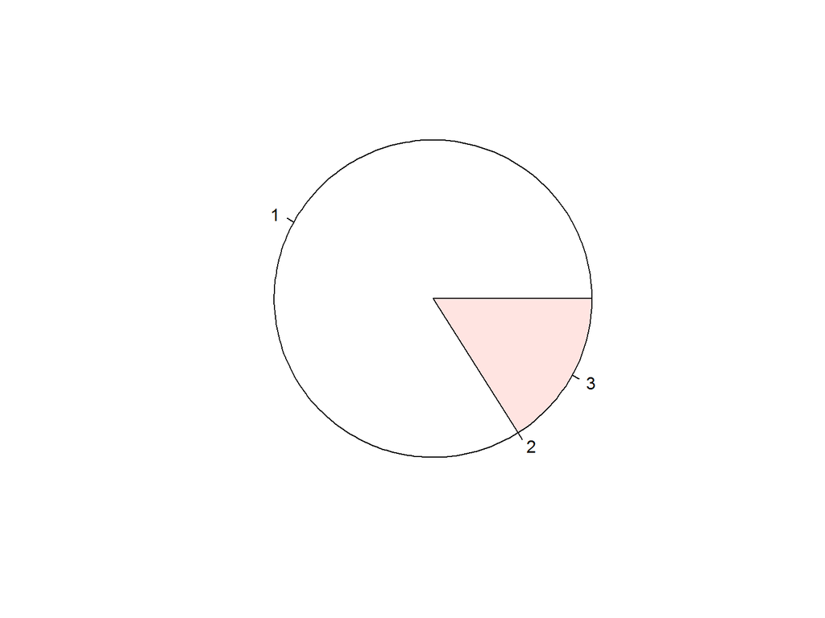

fld_bsqxs变速器形式

```r
fld_bsqxs
```

```
##    fld_bsqxs                含义
## 1          1         CVT无极变速
## 2          2     CVT电子无级变速
## 3          3            手自一体
## 4          4     无级/手动一体式
## 5          5 1档 无级/手动一体式
## 6          6            3档 自动
## 7          7            4档 手动
## 8          8            4档 自动
## 9          9        4档 手自一体
## 10        10            5档 手动
## 11        11            5档 自动
## 12        12        5档 手自一体
## 13        13    5档 连续手自一体
## 14        14 5档 无级/手动一体式
## 15        15            6档 手动
## 16        16            6档 自动
## 17        17        6档 手自一体
## 18        18    6档 连续手自一体
## 19        19 6档 无级/手动一体式
## 20        20        6档 无极变速
## 21        21            7档 自动
## 22        22        7档 手自一体
## 23        23 7档 无级/手动一体式
## 24        24        8档 手自一体
## 25        25 8档 无级/手动一体式
## 26        26            8档 自动
```

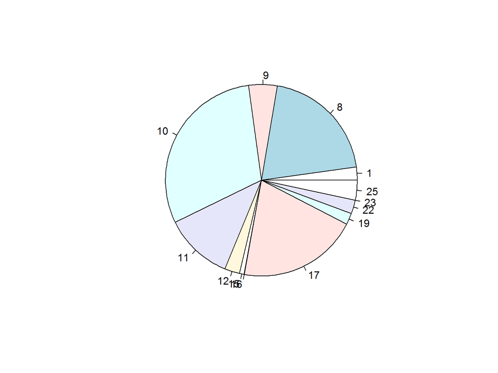

fld_pfsp排放标准

```
##
##      国Ⅰ      国Ⅱ      国Ⅲ 国Ⅲ带OBD      国Ⅳ      国Ⅴ   化油器
##     5106   130868   174166    59005   342603      103     1662
```

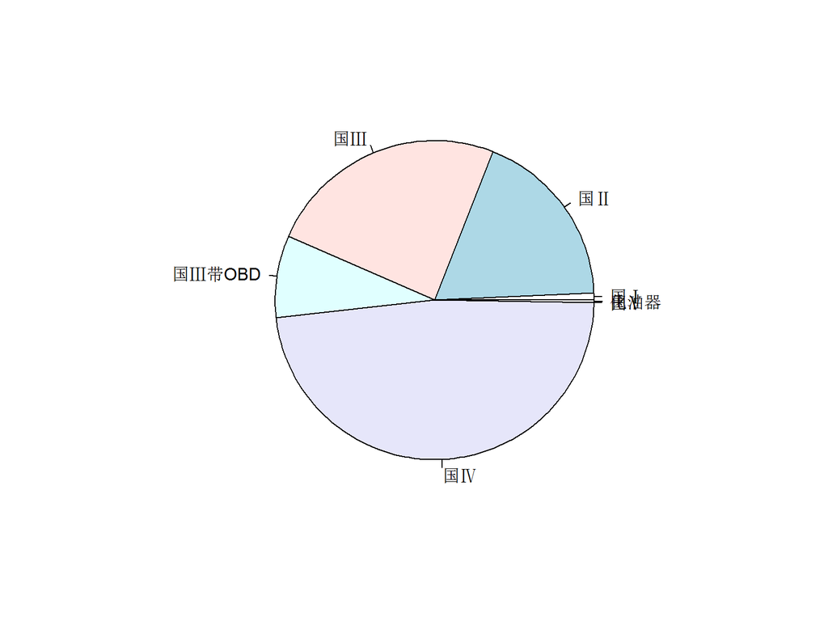

fld_bxq车辆保修期

```
##
##  2年/4万公里  2年/5万公里  2年/6万公里 2年/不限公里 3年/10万公里
##        44942        63966       503095        20654        57552
##  3年/8万公里 5年/10万公里
##         1370        21934
```

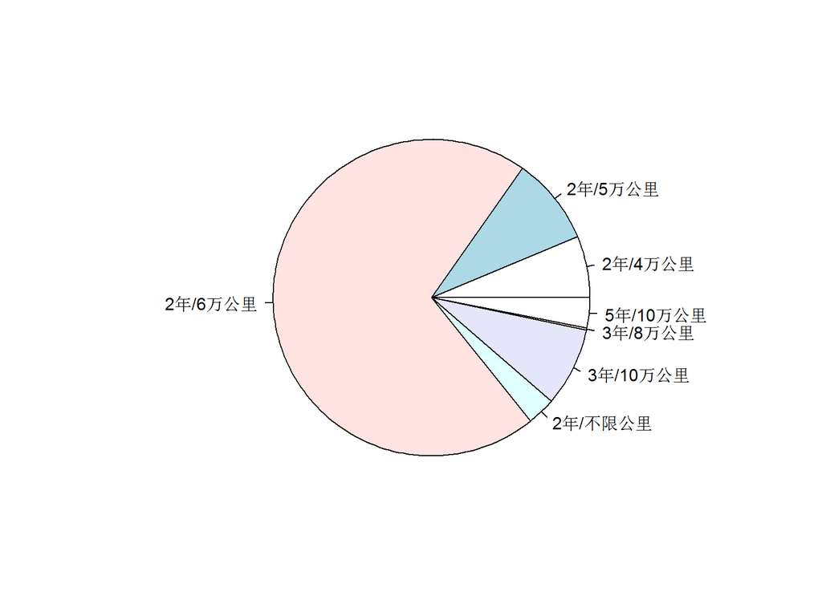

fld_color车身颜色

```
##        Var1   Freq
## 1                4
## 2       ???      1
## 3        白    218
## 4      白红      1
## 5    白红黄      6
## 6    白红灰      1
## 7    白红绿      2
## 8      白黄     27
## 9      白灰    197
## 10     白蓝      3
## 11     白绿      2
## 12     白色  74086
## 13     宝蓝      1
## 14     橙色   1430
```

[output cut: 45 more lines]

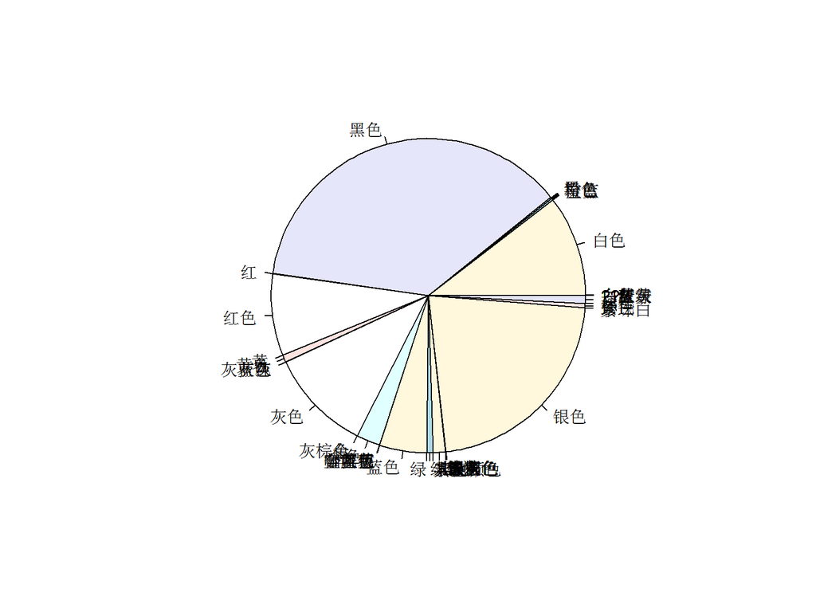

fld_price新车购买当年的厂商指导价

```
## car_data_2009_2014$fld_price
##       n missing  unique    Info    Mean     .05     .10     .25     .50
##  713513       0     528       1   18.45   10.49   11.48   12.98   16.69
##     .75     .90     .95
##   23.68   26.98   29.98
##
## lowest :  7.35  7.48  7.58  7.68  7.98
## highest: 46.45 46.96 47.12 53.88 57.81
```

[figure not shown]

fld_appraise二手车在线报价

```
## car_data_2009_2014$fld_appraise
##       n missing  unique    Info    Mean     .05     .10     .25     .50
##  713513       0    2691       1   10.78    4.20    5.10    6.88    9.20
##     .75     .90     .95
##   13.50   18.78   22.30
##
## lowest :    0.0000    0.0001    0.0100    0.0950    0.1000
## highest:  258.0000  288.0000  338.0000  554.0000 1911.0000
```

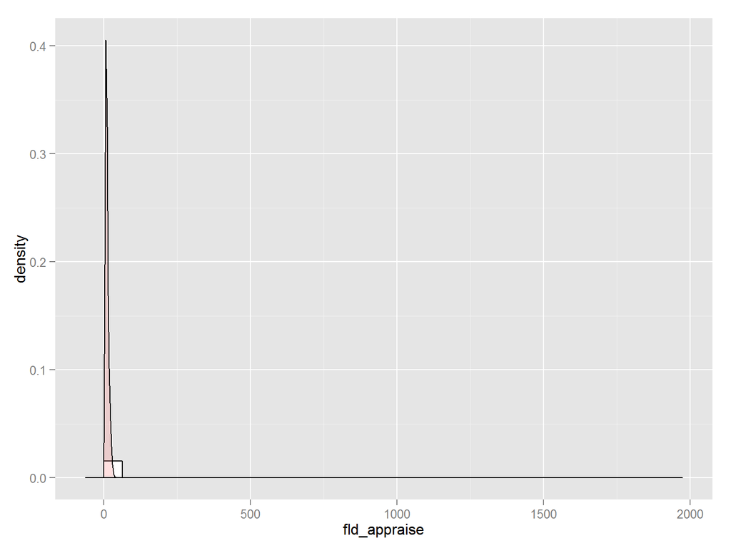

fld_dealprice二手车销售价,此变量缺失值太多,基本不可用

```
## car_data_2009_2014$fld_dealprice
##       n missing  unique    Info    Mean     .05     .10     .25     .50
##  235289  478224    2353       1    8.87     0.0     0.0     4.0     7.5
##     .75     .90     .95
##    11.0    16.0    20.0
##
## lowest :    0.0000    0.0001    0.0004    0.0005    0.0006
## highest: 3532.0000 4111.0000 4224.0000 4444.0000 4567.0000
```

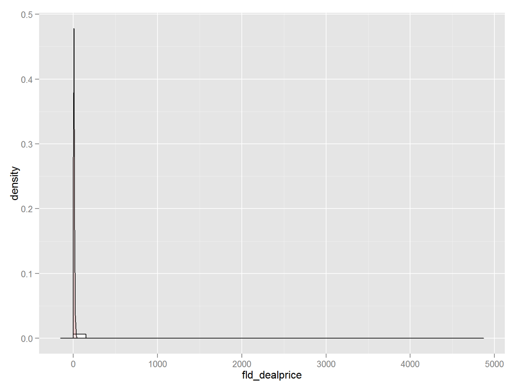

fld_ycyt车辆用途

```
##     Var1   Freq
## 1          2986
## 2   ????      1
## 3 非营运 204726
## 4   家用 502248
## 5   其他    358
## 6   其它    619
## 7   营运   2574
## 8   租赁      1
```

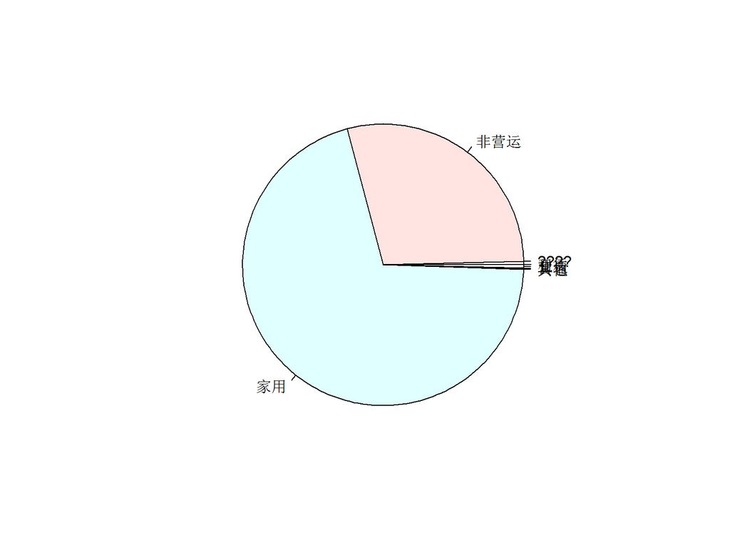

fld_mileage行驶公里数

```
## car_data_2009_2014$fld_mileage
##       n missing  unique    Info    Mean     .05     .10     .25     .50
##  713513       0    8799    0.95    33.1    0.00    0.00    0.00    3.00
##     .75     .90     .95
##    6.89   10.00   13.00
##
## lowest : -6.000e+00  0.000e+00  1.000e-04  1.600e-04  2.100e-04
## highest:  2.101e+05  2.400e+05  3.000e+05  5.347e+05  6.000e+05
```

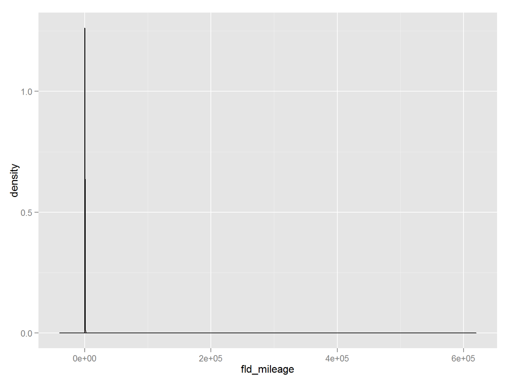

fld_Hits信息点击次数，这个变量基本不可用

```
## car_data_2009_2014$fld_hits
##       n missing  unique    Info    Mean     .05     .10     .25     .50
##  713513       0    3586       1   132.8       0       0      23      80
##     .75     .90     .95
##     144     262     413
##
## lowest :     0     1     2     3     4
## highest: 19093 19914 22203 23511 85770
```

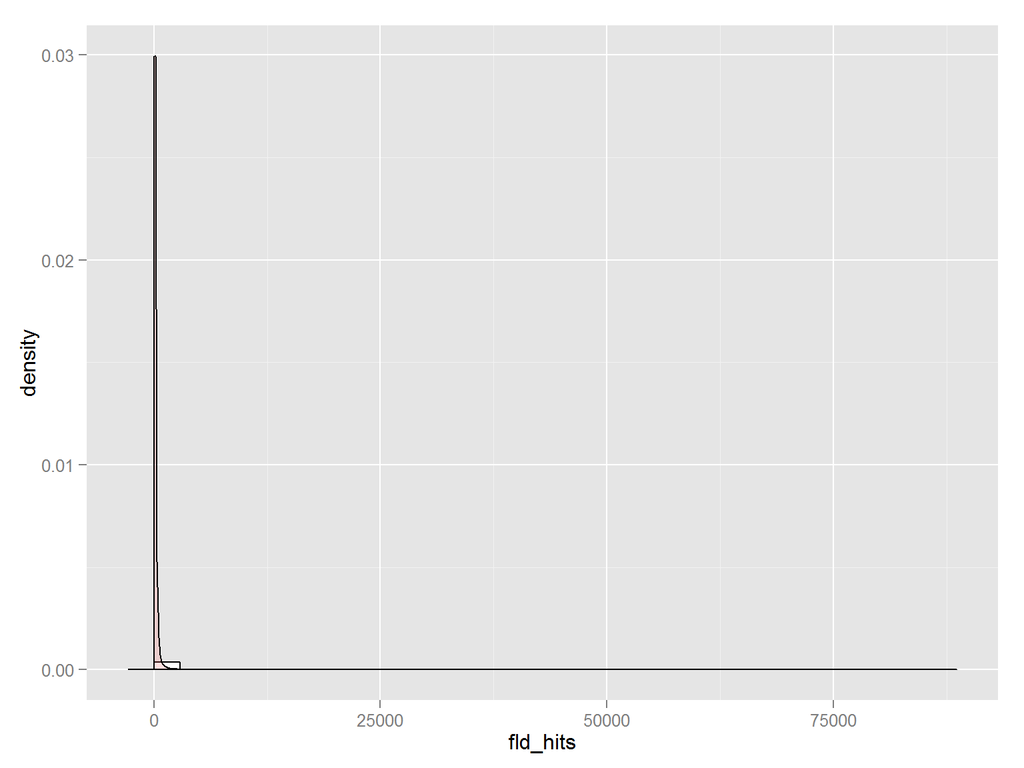

fld_ctlx2车体类型分为3类：1：单厢；2：两厢；3：三厢。

```
##
##          2          3
## 0.08876082 0.91123918
```

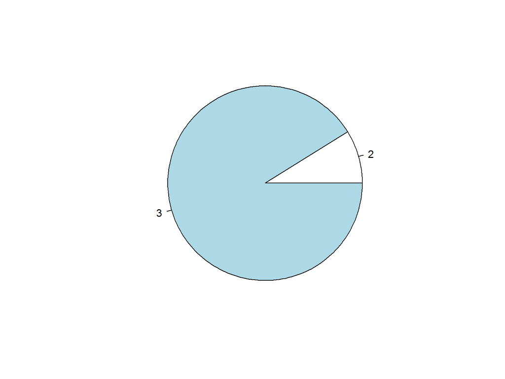

fld_rllxbh燃油类型编号

```r
fld_rllxbh
```

```
##    fld_rllxbh                        含义
## 1           1                 无铅汽油98#
## 2           2                 无铅汽油97#
## 3           3          无铅汽油97#/电混合
## 4          14                 无铅汽油95#
## 5           4                 无铅汽油93#
## 6           5 无铅汽油93#/压缩天然气(CNG)
## 7          13 无铅汽油93#/液化石油气(LPG)
## 8           6                 无铅汽油90#
## 9           8          无铅汽油90#/电混合
## 10          9 无铅汽油90#/压缩天然气(CNG)
## 11         18 无铅汽油90#/液化石油气(LPG)
## 12         10                      柴油0#
## 13         11                      柴油5#
## 14         12                    柴油-10#
## 15         15                    柴油-20#
## 16         16                    柴油-35#
## 17         17                    柴油-50#
## 18         18             压缩天然气(CNG)
## 19         19             液化石油气(LPG)
```

```
##
##      2      3      4      5      6      7     10     12     13     14
##  58712    440 605186   2599  30979    426   1257    281   1003   7972
##     21     30
##   4576     82
```

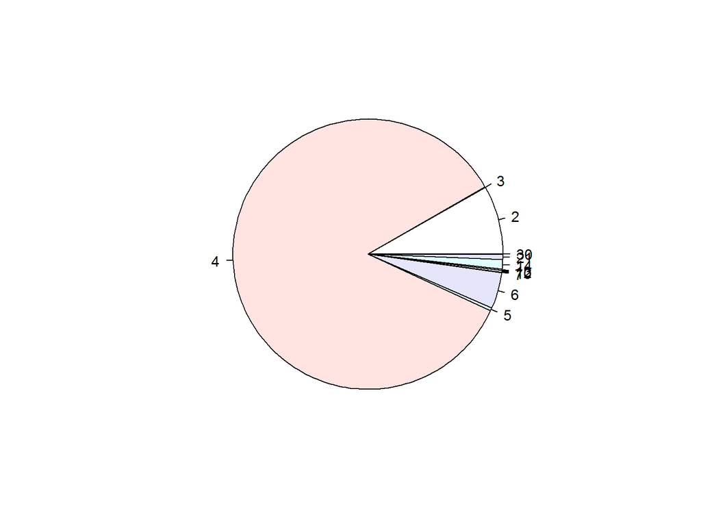

fld_zj轴距

```
## car_data_2009_2014$fld_zj
##       n missing  unique    Info    Mean     .05     .10     .25     .50
##  713513       0      36    0.99    2679    2471    2513    2600    2685
##     .75     .90     .95
##    2775    2837    2850
##
## lowest : 2471 2511 2513 2535 2578, highest: 2812 2837 2850 2869 2900
```

```
## stat_bin: binwidth defaulted to range/30. Use 'binwidth = x' to adjust this.
```

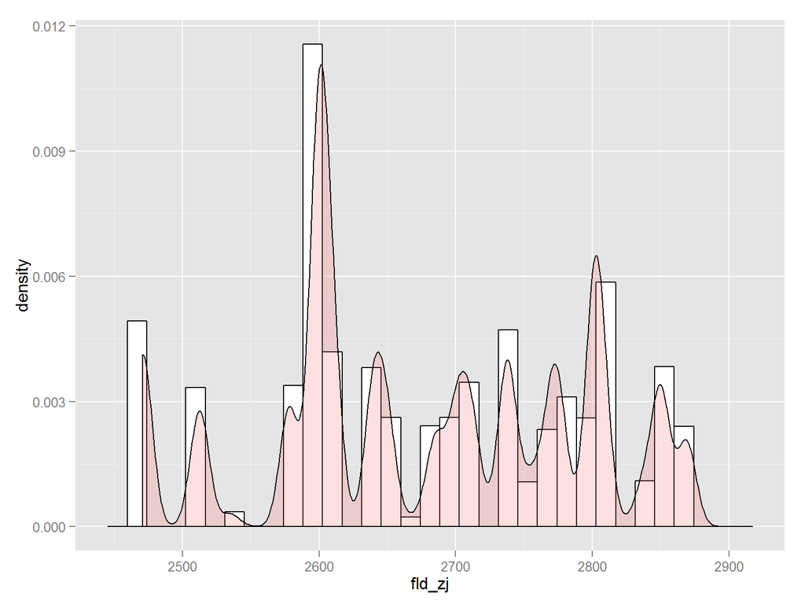

fld_zbzl整车质量(kg)

```
## car_data_2009_2014$fld_zbzl
##       n missing  unique    Info    Mean     .05     .10     .25     .50
##  713513       0     191       1    1382    1105    1165    1260    1360
##     .75     .90     .95
##    1535    1582    1615
##
## lowest :    0 1021 1030 1032 1041, highest: 1750 1765 1770 1800 1850
```

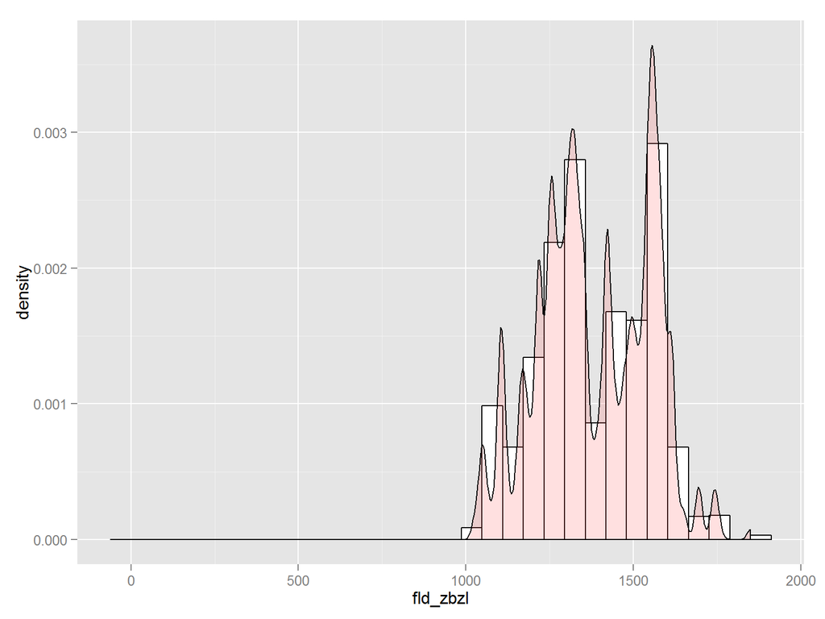

fld_fzxs风阻系数(cd) 风阻系数，因为12%的风阻系数为零，不用这个变量

```
##
##     0  0.27  0.28  0.29   0.3  0.31  0.32 0.338  0.34  0.36
## 12.02  2.45 13.89  6.53 12.56 12.35 14.30  7.49 18.37  0.03
```

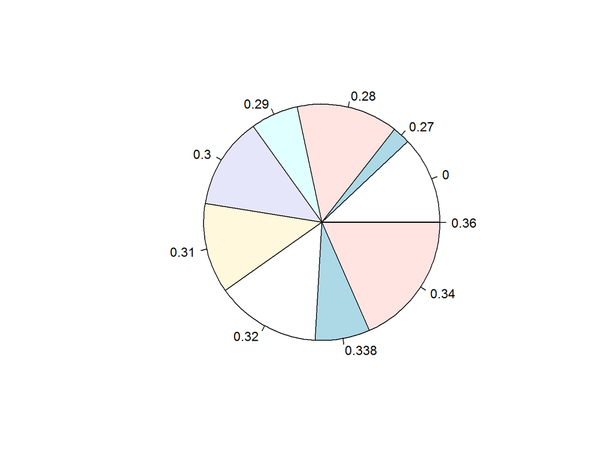

fld_jssj:0―100km/h加速时间(s)起码要大于5S

```
## car_data_2009_2014$fld_jssj
##       n missing  unique    Info    Mean     .05     .10     .25     .50
##  713513       0      83    0.99   9.061     0.0     0.0     8.2    11.8
##     .75     .90     .95
##    12.7    13.5    13.7
##
## lowest :  0.0  6.0  6.1  6.7  6.9, highest: 15.5 15.9 16.0 16.5 18.2
```